# Report Capstone

DM

Saturday, July 25, 2015

## Executive summary

This is an R Markdown document written as a report on data for project in Data Science Specialisation. Goal of the project is make prediction of the following word based on privious words. For more details about Project see Johns Hopkins Data Science Capstone, https://www.coursera.org/course/dsscapstone.

- Data acquisition and data summary - info how to get data and size of the data
- Cleaning data - how to remove parts of the data not useful for further analysis
- Exploratory analysis about the data
- Some modelling ideas

## Data acquisition and data summary

Data are obtained from link: *“http://d396qusza40orc.cloudfront.net/dsscapstone/dataset/Coursera-SwiftKey.zip”*. File is unziped and only en-US data is analysed. We have three files that we saved in folder corpus under project’s main directory. Names of the files are:

- en_US.blogs.txt
- en_US.news.txt
- en_US.twitter.txt

Info about size of the files (in MBs):

```r
file.info("./corpus/en_US.blogs.txt")$size   / 1024^2
```

```
## [1] 200.4242
```

```r
file.info("./corpus/en_US.news.txt")$size    / 1024^2
```

```
## [1] 196.2775
```

```r
file.info("./corpus/en_US.twitter.txt")$size / 1024^2
```

```
## [1] 159.3641
```

Blogs data has aprox. 900k lines, News data approx. 77k lines and Twitter data approx. 2.3M lines. Info about the number of lines is posibble to optain by commands like:

```r
length(readLines("./corpus/en_US.blogs.txt"))
```

Next, we read first nlines from the files to get some insite about the words in the files. We use that nlines of the files to combine a new dataset for text mining corpus.

```r
nlines<-3000
file.blogs<-file("./corpus/en_US.blogs.txt")
blogs<-readLines(file.blogs,encoding="UTF-8",nlines,skipNul=TRUE)
close(file.blogs)

file.news<-file("./corpus/en_US.news.txt")
news<-readLines(file.news,encoding="UTF-8",nlines,skipNul=TRUE)
close(file.news)

file.twitter<-file("./corpus/en_US.twitter.txt")
twitts<-readLines(file.twitter,encoding="UTF-8",nlines,skipNul=TRUE)
close(file.twitter)

data <- paste(blogs,news,twitts) #combined data
```

## Cleaning the data

First, we have to read necessary packages to generate text mining corpus.

```r
library(NLP)
library(tm)
library(SnowballC)
library(RWeka)
```

Then we generate corpus to do the analysis of the text data.

```r
data<-VectorSource(data)
corpus<-VCorpus(data)
```

To be sure that our corpus is clean we can remove everythig that different from letters followed by space.

```r
removeNumPunct <- function(x) gsub("[^[:alpha:][:space:]]*", "", x)
corpus <- tm_map(corpus, content_transformer(removeNumPunct))
```

We coud do analysis more pricise by removing punctuation, numbers, set tellers to lowers, remove white spaces that are not useful. Effect is similar, but maybe in some case difference may be significant. In our case, in our opinion, it is not.

We do the steeming of the words, too.

Usually, stopwords are also removed, but our goal is to predict next word so we need to keep all words.

```r
corpus <- tm_map(corpus, removePunctuation)
corpus <- tm_map(corpus, removeNumbers)
corpus <- tm_map(corpus, content_transformer(tolower))
corpus <- tm_map(corpus, stripWhitespace)
corpus <- tm_map(corpus, stemDocument)
```

## Exploratory analysis

For exploratory analysis we use RWeka, package that connects R and Weka. Weka has a large variety of algorithms included and we use those for text mining - extracting n-grams from text.

Preparing data for Weka.

```r
corpus<-data.frame(text=unlist(sapply(corpus, `[`, "content")), stringsAsFactors=F)
```

### Tokenisation

Genrating tokens with 1, 2, 3 and 4 words.

```r
token.1w <- NGramTokenizer(corpus, Weka_control(min = 1, max = 1))
token.2w <- NGramTokenizer(corpus, Weka_control(min = 2, max = 2, delimiters = " \\r\\n\\t.,;:\"()?!"))
token.3w <- NGramTokenizer(corpus, Weka_control(min = 3, max = 3, delimiters = " \\r\\n\\t.,;:\"()?!"))
token.4w <- NGramTokenizer(corpus, Weka_control(min = 4, max = 4, delimiters = " \\r\\n\\t.,;:\"()?!"))
```

Saving data in form of data frames.

```r
df1 <- data.frame(table(token.1w))
df2 <- data.frame(table(token.2w))
df3 <- data.frame(table(token.3w))
df4 <- data.frame(table(token.4w))

df1.sorted <- df1[order(df1$Freq,decreasing = TRUE),]
df2.sorted <- df2[order(df2$Freq,decreasing = TRUE),]
df3.sorted <- df3[order(df3$Freq,decreasing = TRUE),]
df4.sorted <- df4[order(df4$Freq,decreasing = TRUE),]
```

# saving 15 most frequent-grams

```r
num=15
one   <- df1.sorted[1:num,]
two   <- df2.sorted[1:num,]
three <- df3.sorted[1:num,]
four  <- df4.sorted[1:num,]

colnames(one)   <- c("Word","Frequency"); rownames(one) <- c(1:15)
colnames(two)   <- c("Word","Frequency"); rownames(two) <- c(1:15)
colnames(three) <- c("Word","Frequency"); rownames(three) <- c(1:15)
colnames(four)  <- c("Word","Frequency"); rownames(four) <- c(1:15)
```

### Distributions of word frequencies

### Tables of the frequencies

Most frequent words:

```r
head(one,5)
```

```
##   Word Frequency
## 1  the     13095
## 2   to      7208
## 3  and      6853
## 4    a      6317
## 5   of      5591
```

Most frequent combinations of two words:

```r
head(two,5)
```

```
##      Word Frequency
## 1  of the      1194
## 2  in the      1129
## 3  to the       584
## 4 for the       503
## 5  on the       492
```

Most frequent combinations of three words:

```r
head(three,5)
```

```
##          Word Frequency
## 1  one of the        98
## 2    a lot of        96
## 3   i want to        59
## 4    go to be        44
## 5 part of the        43
```

Most frequent combinations of four words:

```r
head(four,5)
```

```
##                 Word Frequency
## 1     the end of the        19
## 2    the rest of the        17
## 3      at the end of        16
## 4 for the first time        16
## 5    when it come to        15
```

### Plots of the word frequencies

Most frequent words:

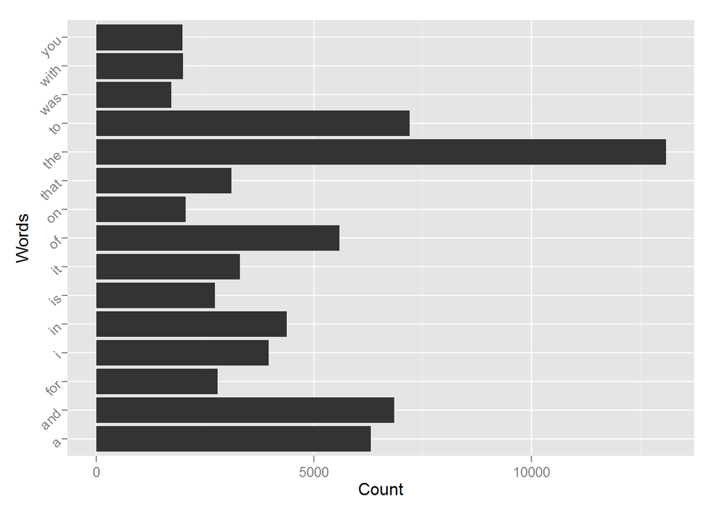

```r
library(ggplot2)
ggplot(one, aes(x=Word,y=Frequency), ) + geom_bar(stat="Identity")+ theme(axis.text.y = element_text(angle = 45, hjust = 1))+ xlab("Words") + ylab("Count") + coord_flip()
```

Most frequent combinations of two words:

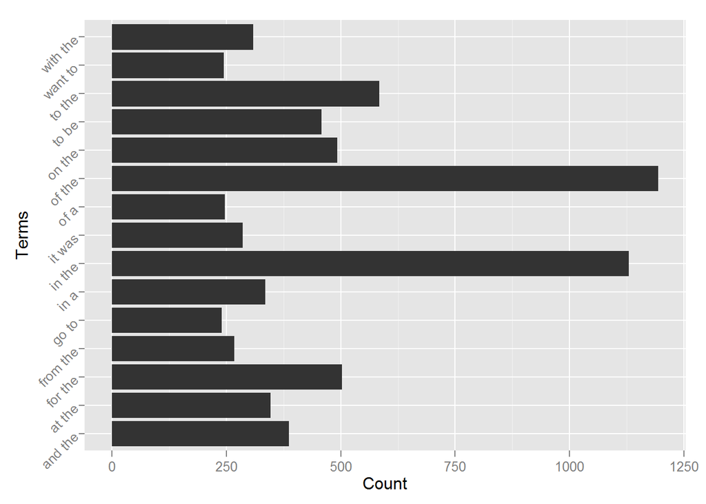

```r
ggplot(two, aes(x=Word,y=Frequency), ) + geom_bar(stat="Identity")+ theme(axis.text.y = element_text(angle = 45, hjust = 1))+ xlab("Terms") + ylab("Count") + coord_flip()
```

Most frequent combinations of three words:

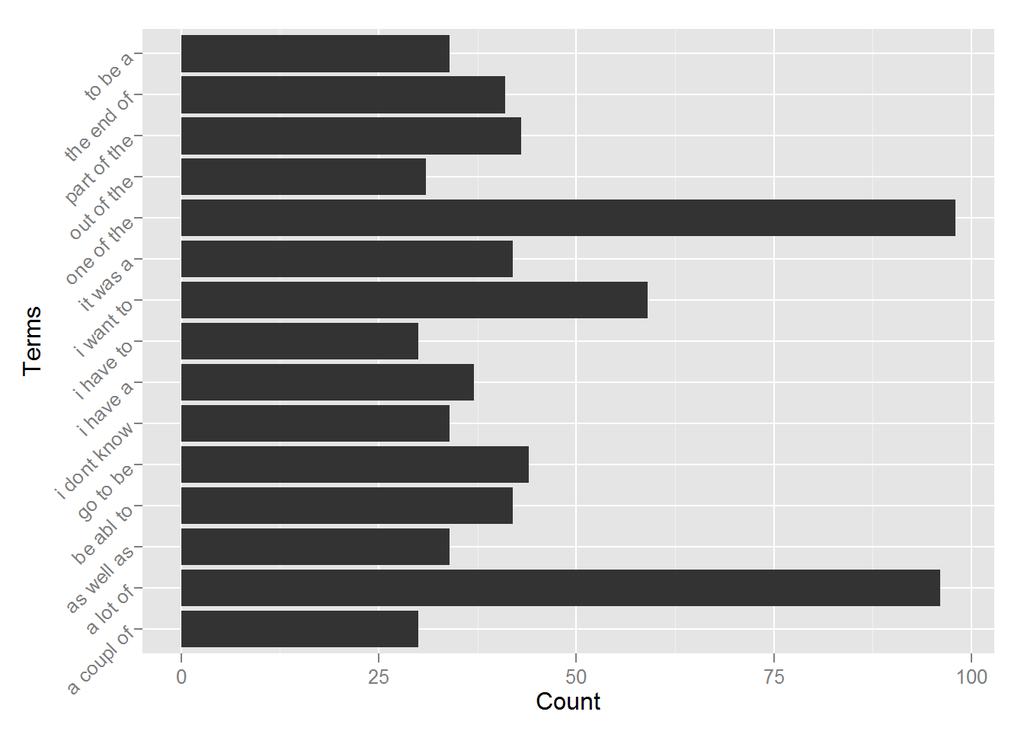

```r
ggplot(three, aes(x=Word,y=Frequency), ) + geom_bar(stat="Identity")+ theme(axis.text.y = element_text(angle = 45, hjust = 1))+ xlab("Terms") + ylab("Count") + coord_flip()
```

Most frequent combinations of four words:

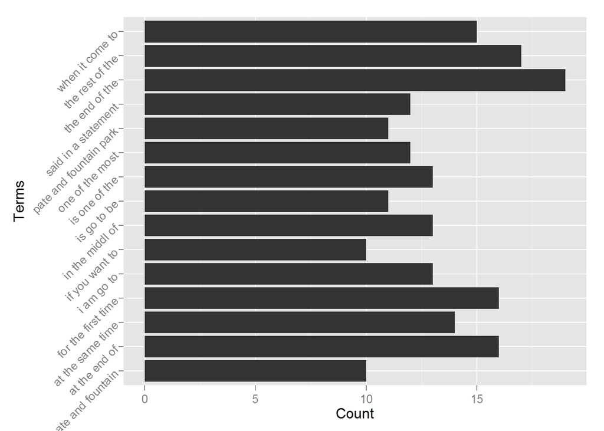

```r
ggplot(four, aes(x=Word,y=Frequency), ) + geom_bar(stat="Identity")+ theme(axis.text.y = element_text(angle = 45, hjust = 1))+ xlab("Terms") + ylab("Count") + coord_flip()
```

### Other plots

Cloud plots for most frequent one and combinations of two words:

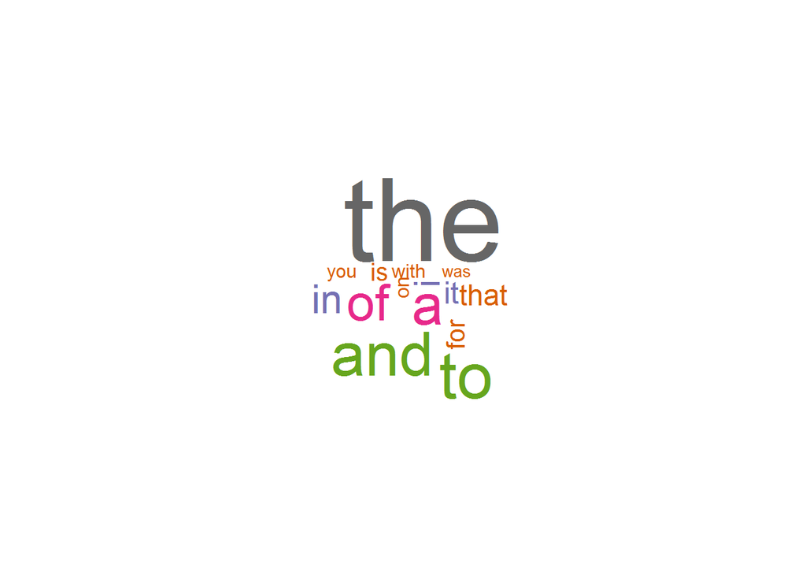

```r
library(wordcloud);library(RColorBrewer)
with(one,wordcloud(Word, Frequency, min.freq=5,colors=brewer.pal(8,"Dark2"),scale= c(6, .1)))
```

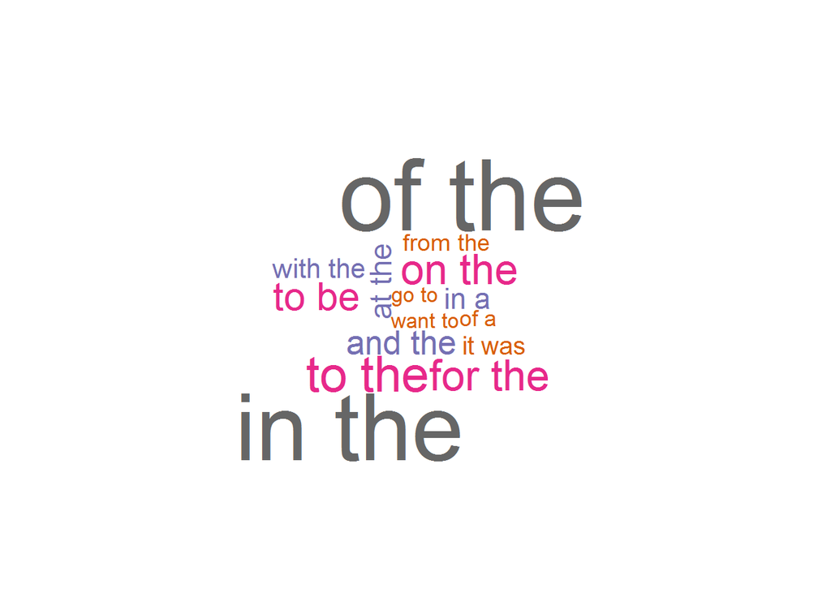

```r
with(two,wordcloud(Word, Frequency, min.freq=3,colors=brewer.pal(8,"Dark2"),scale= c(5, .1)))
```

## Modeling ideas

Goal of the projest is to build a simple model for prediction of the word that writter wants to write. For that purpuse we have intention to:

- use n-grams to if text is potentialy part of 2-gram, 3gram, 4-gram,
- find unfrequent words, and try to find high correlated unfriequent words.
- all together is formedad as Markov Chain where function returns three word with highest probability of occurance.